# EDA: COVID-19 and Brent Crude Oil

Justin Huang and So I Kwak

## Libraries

```r
rm(list=ls())

# install.packages("tidyquant")
library(tidyverse)
library(tidyquant)
```

# Guiding Question

Has the advent of COVID-19 had a significant impact on futures prices for Brent Crude Oil? If so, how has it been affected and where might it go in the foreseeable future?

# Primary data: COVID-19 Cases

### Load Global Data

*uses absolute file paths, change for your system*

```r
dir = "~/Development/stat184/brent-covid-19/COVID-19/csse_covid_19_data/csse_covid_19_time_series"

Confirmed <-
  read.csv(file.path(dir,
                     "time_series_covid19_confirmed_global.csv")) %>%
    pivot_longer(cols=c(starts_with("X")), names_to="date", values_to="confirmed")

Deaths <-
  read.csv(file.path(dir,
                     "time_series_covid19_deaths_global.csv")) %>%
    pivot_longer(cols=c(starts_with("X")), names_to="date", values_to="deaths")

Recovered <-
  read.csv(file.path(dir,
                     "time_series_covid19_recovered_global.csv")) %>%
    pivot_longer(cols=c(starts_with("X")), names_to="date", values_to="recovered")

# get all data in one data table, and make everything tidy
COVID19 <-
  Confirmed %>%
    left_join(Deaths %>% select(-c(Lat, Long)),
              by=c('Province.State' = 'Province.State',
                   'Country.Region' = 'Country.Region',
                   'date'='date')) %>%
    left_join(Recovered %>% select(-c(Lat, Long)),
              by=c('Province.State' = 'Province.State',
                   'Country.Region' = 'Country.Region',
                   'date'='date')) %>%
    rename(c("province.state"="Province.State",
             "country.region"="Country.Region",
             "lat"="Lat",
             "long"="Long")) %>%
    mutate(date = lubridate::mdy(gsub(pattern = "^X", replacement="", date)))
```

```
Column `Province.State` joining factors with different levels, coercing to character vector
```

### Summary of Primary Data

```r
summary(COVID19)
```

```
 province.state            country.region       lat               long              date
 Length:21120       China         : 2640   Min.   :-51.796   Min.   :-135.00   Min.   :2020-01-22
 Class :character   Canada        : 1200   1st Qu.:  6.969   1st Qu.: -20.03   1st Qu.:2020-02-10
 Mode  :character   France        :  880   Median : 23.488   Median :  20.54   Median :2020-03-01
                    United Kingdom:  880   Mean   : 21.317   Mean   :  22.17   Mean   :2020-03-01
                    Australia     :  640   3rd Qu.: 41.166   3rd Qu.:  78.75   3rd Qu.:2020-03-21
                    Netherlands   :  400   Max.   : 71.707   Max.   : 178.06   Max.   :2020-04-10
                    (Other)       :14480
   confirmed          deaths           recovered
 Min.   :     0   Min.   :    0.00   Min.   :    0.0
 1st Qu.:     0   1st Qu.:    0.00   1st Qu.:    0.0
 Median :     1   Median :    0.00   Median :    0.0
 Mean   :  1122   Mean   :   55.37   Mean   :  292.2
 3rd Qu.:    78   3rd Qu.:    1.00   3rd Qu.:    5.0
 Max.   :496535   Max.   :18849.00   Max.   :64236.0
                                     NA's   :1200
```

```r
tail(COVID19)
```

| province.state | country.region | lat | long | date | confirmed | deaths | recovered |
| --- | --- | --- | --- | --- | --- | --- | --- |
|  | Yemen | 15.55273 | 48.51639 | 2020-04-05 | 0 | 0 | 0 |
|  | Yemen | 15.55273 | 48.51639 | 2020-04-06 | 0 | 0 | 0 |
|  | Yemen | 15.55273 | 48.51639 | 2020-04-07 | 0 | 0 | 0 |
|  | Yemen | 15.55273 | 48.51639 | 2020-04-08 | 0 | 0 | 0 |
|  | Yemen | 15.55273 | 48.51639 | 2020-04-09 | 0 | 0 | 0 |
|  | Yemen | 15.55273 | 48.51639 | 2020-04-10 | 1 | 0 | 0 |

We have three categorical variables (province.state, country.region, date) and three quantitative variables that describe the number of people affected by the coronavirus (confirmed, deaths, recovered). Additionally, we have lat and long but I declined to include these as they’re not extremely pertinent to the overall analysis.

### Analysis

# Secondary Data

### Load Brent Crude Oil

```r
Brent <-
  tq_get("BZ=F", from=mdy("1.22.2020")) %>%
    select(-symbol) %>%
    # Get rid of NA rows where trading wasn't open
    drop_na()
```

Conveniently, this is already in tidy form, so there’s a lot less data wrangling to initially do.

### Summary of Secondary Data

```r
tail(Brent)
```

| date | open | high | low | close | volume | adjusted |
| --- | --- | --- | --- | --- | --- | --- |
| 2020-04-02 | 27.23 | 32.60 | 25.96 | 29.82 | 25611657 | 29.82 |
| 2020-04-03 | 28.86 | 35.00 | 28.28 | 34.78 | 26017704 | 34.78 |
| 2020-04-06 | 33.40 | 34.23 | 31.90 | 33.73 | 15708495 | 33.73 |
| 2020-04-07 | 33.87 | 34.16 | 31.73 | 32.66 | 13950604 | 32.66 |
| 2020-04-08 | 32.65 | 33.87 | 31.55 | 33.75 | 13377399 | 33.75 |
| 2020-04-09 | 33.43 | 36.43 | 31.24 | 31.87 | 18329230 | 31.87 |

```r
summary(Brent)
```

```
      date                 open            high            low            close           volume
 Min.   :2020-01-22   Min.   :23.16   Min.   :23.67   Min.   :21.69   Min.   :22.72   Min.   :     901
 1st Qu.:2020-02-10   1st Qu.:32.36   1st Qu.:33.94   1st Qu.:29.82   1st Qu.:31.97   1st Qu.: 6199791
 Median :2020-03-01   Median :52.68   Median :53.08   Median :51.05   Median :51.62   Median :13709894
 Mean   :2020-02-29   Mean   :45.10   Mean   :46.00   Mean   :43.61   Mean   :44.70   Mean   :12986775
 3rd Qu.:2020-03-19   3rd Qu.:56.89   3rd Qu.:57.38   3rd Qu.:56.00   3rd Qu.:56.80   3rd Qu.:18290329
 Max.   :2020-04-09   Max.   :64.34   Max.   :64.39   Max.   :62.62   Max.   :62.76   Max.   :39116318
    adjusted
 Min.   :22.72
 1st Qu.:31.97
 Median :51.62
 Mean   :44.70
 3rd Qu.:56.80
 Max.   :62.76
```

We have one categorical variable (date) and the rest are quantitative variables (OHLC values, volume, adjusted close). You’ll notice that there were a good amount of NA rows because trading wasn’t available on that specific day, so we cleaned those up.

### Analysis

# Preliminary Exploration

### COVID-19

#### Global Comparison

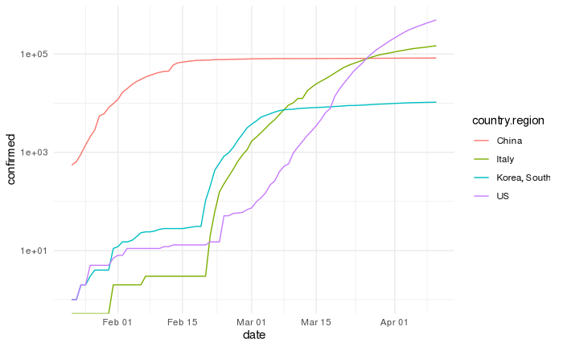

```r
COVID19 %>%
  filter(country.region %in% c("US", "China", "Korea, South", "Italy")) %>%
  group_by(country.region, date) %>%
  summarise(confirmed=sum(confirmed)) %>%
  ggplot(aes(date, confirmed)) +
    geom_line(aes(color=country.region)) +
    scale_y_log10()+
    theme_minimal()
```

Log scale of coronavirus cases in China, Italy, South Korea and the United States. We can see that China and South Korea have long since plataued in new confirmed cases, while the US and Italy are still in the thick of it. Something very noteworthy is how cases in Italy and South Korea began rising at approximately the same date, yet South Korea has been able to control the situation much more effectively than Italy. Of course, there may be other factors involved. In any case, a lot of these numbers are beginning to taper off, which may be indicative of the effectiveness of social distancing.

#### Confirmed, Deaths, Recoveries

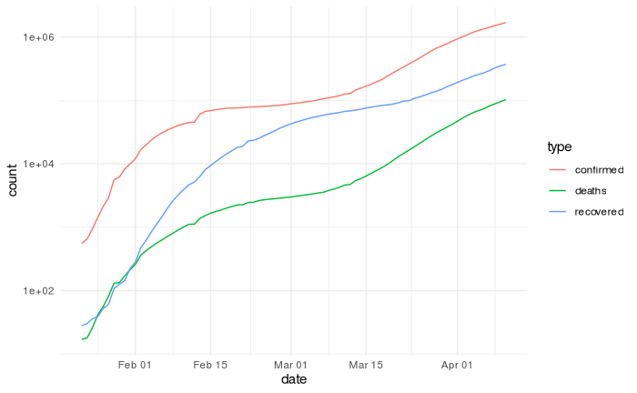

```r
Global <-
  COVID19 %>%
    group_by(date) %>%
    summarise(confirmed=sum(confirmed), deaths=sum(deaths), recovered=sum(recovered, na.rm=TRUE))

Global %>%
  pivot_longer(cols=c(confirmed, deaths, recovered), names_to="type", values_to="count") %>%
  ggplot(aes(date, count)) +
    geom_line(aes(color=type)) +
    scale_y_log10() +
    theme_minimal()
```

Log scale of confirmed cases and deaths from COVID-19 globally. We can see that they essentially follow the same trends, which makes sense. Recoveries actually seem to grow faster than deaths, which is expected but still heartening.

### Brent Crude Oil

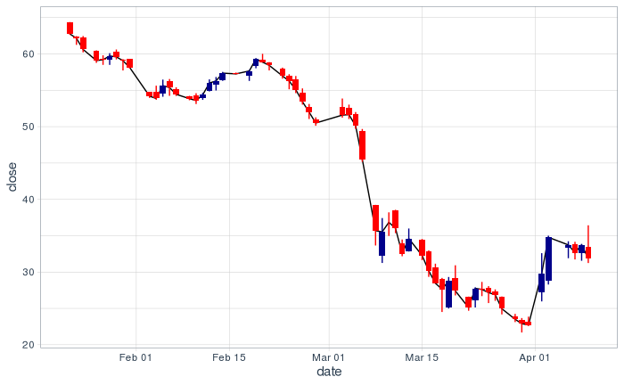

```r
Brent %>%
  ggplot(aes(date, close)) +
    geom_line() +
    geom_candlestick(aes(open=open, high=high, low=low, close=close)) +
    theme_tq()
```

We can see that Brent crude oil futures prices tanked starting in January. I wonder what happened? Hmm.

Despite its hardships, it’s also begun to rebound well since the beginning of April.

One key thing to note about the price of Brent crude is the price war between Russia and OPEC that first started on March 6, when Russia refused to cut production in conjunction with Saudia Arabia because of a sharp fall in demand because of COVID-19 and stay-at-home procedures. While an agreement between Russia and Saudi Arabia was reached on April 9 to cut production by 10 million barrels per day, the situation is still evolving because of a lack of commitment from Mexico (source: [Bloomberg](https://www.bloomberg.com/news/articles/2020-04-10/mexico-reaches-oil-output-cuts-agreement-with-opec-and-trump)).

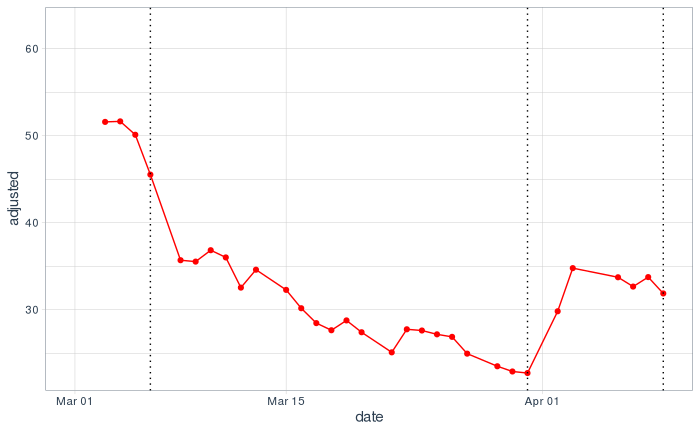

```r
Brent %>%
  ggplot(aes(date, adjusted)) +
    geom_line(color = "red") +
    geom_point(color = "red") +
    geom_vline(aes(xintercept=mdy("3-6-2020")), linetype=3) +
    geom_vline(aes(xintercept=mdy("3-31-2020")), linetype=3) +
    geom_vline(aes(xintercept=mdy("4-9-2020")), linetype=3) +
    xlim(mdy("3-1-2020"), mdy("4-9-2020")) +
    theme_tq()
```

While this price war was certainly caused by a fall in demand due to COVID-19, it’s important to keep this information in mind moving forward.

### COVID-19 and Brent Crude Oil

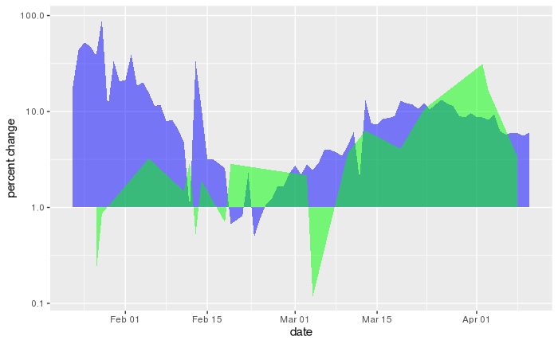

```r
Global <-
  Global %>%
    mutate(confirmed_delta = (confirmed/lag(confirmed)-1)*100,
         deaths_delta = (deaths/lag(deaths)-1)*100,
         recovered_delta = (recovered/lag(recovered)-1)*100)

Brent <-
  Brent %>%
    mutate(close_delta = (close/lag(close)-1)*100)

Global %>%
  ggplot(aes(x=date)) +
    geom_area(aes(y=confirmed_delta), fill = "blue", alpha = 0.5) +
    geom_area(data = Brent, aes(date, close_delta), fill = "green", alpha = 0.5) +
    scale_y_log10() +
    ylab("percent change")
```

In this graph, it’s hard to see any correlation between percent change in COVID-19 confirmed cases and Brent Crude Oil prices. Let’s try again.

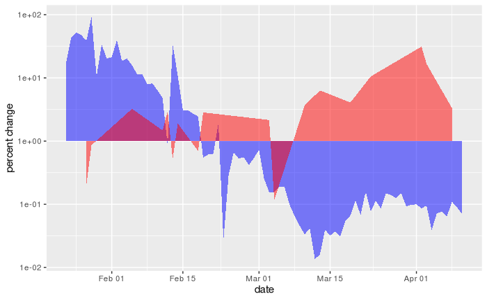

```r
COVID19 %>%
  filter(country.region=="China") %>%
  group_by(date) %>%
  summarise(confirmed=sum(confirmed)) %>%
  mutate(confirmed_delta = (confirmed/lag(confirmed)-1)*100) %>%
  ggplot(aes(date)) +
    geom_area(aes(y=confirmed_delta), fill="blue", alpha = 0.5) +
    geom_area(data =Brent, aes(date, close_delta), fill="red", alpha = 0.5) +
    scale_y_log10() +
    ylab("percent change")
```

This one’s interesting, because you can see more of a negative relationship between percent change in close prices and China’s confirmed cases (scaled by log10). However, this might be a red herring because the actual percent change of China in March and April is close to 0, and we all know that log(0) is not pretty.

# EDA: Projections

When modeling populations and growth, the logistic growth model becomes very handy. In the following examples, we will first use Hubei, China as an example of how the logistic growth model matches up with our data, and then project values for Italy and US. We’ll also see how the data matches with Brent.

## Hubei, China

```r
logistic_model = function(nls_model, xvar, df) {
  # Values for the logistic growth model
  phi1 <- coef(nls_model)[1]
  phi2 <- coef(nls_model)[2]
  phi3 <- coef(nls_model)[3]

  # Get x value range
  x <- c(min(df[xvar]):(max(df[xvar])+50))

  # Construct model return values and return the resulting data frame
  y <- phi1 / (1 + exp(-(phi2 + phi3 * x)))
  return(data.frame(x, y))
}
```

Function inspired by the logistic growth model example by [Brian Cheng](https://bscheng.com/2014/05/07/modeling-logistic-growth-data-in-r/). The actual creation of the logit model by `nls()` is omitted from the function because creating complicated formulas using strings is hard :(.

```r
brent_graph <-
  Brent %>%
    mutate(datediff = as.numeric(date - mdy("1-22-2020"))) %>%
    ggplot(aes(datediff, close)) +
      geom_line() +
      labs(x='Days Since 1-22-2020', y='Brent Futures Close Price') +
      theme_minimal()
```

```r
Hubei <-
  COVID19 %>%
    filter(province.state=="Hubei") %>%
    mutate(datediff = as.numeric(date - mdy("1-22-2020")))

start <- coef(lm(logit(confirmed/100) ~ datediff, data = Hubei))
```

```
NaNs produced
```

```
Removed 19 rows containing missing values (geom_point).Removed 69 row(s) containing missing values (geom_path).Removed 14 row(s) containing missing values (geom_path).
```

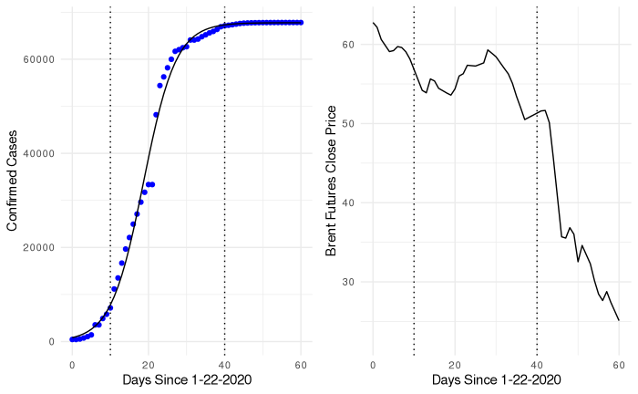

```r
# Important to note that the asymptote, 100000, was an assumption
hubei_nls <- nls(confirmed ~ phi1 / (1 + exp(-(phi2 + phi3 * datediff))),
                  start = list(phi1 = 100000, phi2 = start[[1]], phi3=start[[2]]),
                  data = Hubei)

hubei_logit <- logistic_model(hubei_nls, "datediff", Hubei)

hubei_graph <-
  Hubei %>%
    ggplot(aes(datediff, confirmed))+
      geom_point(color='blue') +
      labs(x='Days Since 1-22-2020', y='Confirmed Cases')+
      geom_line(data=hubei_logit, aes(x, y)) +
      geom_vline(aes(xintercept=10), linetype = 3) +
      geom_vline(aes(xintercept=40), linetype = 3) +
      xlim(0, 60) +
      theme_minimal()

plot_grid(hubei_graph,
          brent_graph +
          geom_vline(aes(xintercept=10), linetype = 3) +
          geom_vline(aes(xintercept=40), linetype = 3) +
          xlim(0, 60))
```

This Hubei examples exists to show that the logistic growth model seems to fit COVID-19 confirmed cases over time well—visually, at least. Let’s check that it actually works.

```r
rss <- sum(residuals(hubei_nls)^2)
tss <- sum((Hubei$confirmed - mean(Hubei$confirmed))^2)
abs(tss-rss)/tss # Calculation of r^2
```

```
[1] 0.9950846
```

That’s a beautiful r-squared value.

Interestingly, there is little effect on the Brent Crude price, since in the range where the cases grew the most, there was almost no net change in Brent Crude up to day 30 (since the prices rebounded) and then began to dip as cases in China began to stabilize. So what *did* affect the oil price?